# statistical_analysis_epistasis

## Fold-Change Data

Here we look at the fold-change data used in the input files. This allows us to see positive and negative functional effects across the landscapes.

```r
fit_land = do.call("rbind", lapply(paste0("trans_Output/", list.files(path = "trans_Output", pattern="observed_values.csv", recursive = T)), read_csv, skip = 1, show_col_types=F, col_names = c("id", "effect", "muts", "junk1", "junk2", "enz")))

## Make fit_land have IDs by finding where muts are 0, i.e. start of new dataset, and multiplying
## Those values by the folder names to generate ID vector

fit_land_spots = c(which(fit_land$muts == 0), (dim(fit_land)[1] + 1)) # Add end of dataset
fit_land_counts = c()

for(i in 1:(length(fit_land_spots) - 1)) {

  if(i == 1) {
    fit_land_counts = c(fit_land_counts, fit_land_spots[i + 1] - 1)
  } else {
    fit_land_counts = c(fit_land_counts, fit_land_spots[i + 1] - fit_land_spots[i])
  }

}

## This assumes folders are read in the order that they are listed

fit_land_ids = rep(str_remove_all(list.files(path = "trans_Output", pattern="observed_values.csv", recursive = T), "/observed_values.csv"), fit_land_counts)

fit_land$unique_id = fit_land_ids

fit_land = fit_land %>% filter(muts != 0)
```

The data shows the following distribution

```r
c(sum(fit_land$effect < log10(1/1.5)), sum(fit_land$effect >= log10(1/1.5) & fit_land$effect <= log10(1.5)), sum(fit_land$effect > log10(1.5)))
```

```
## [1] 256 422 721
```

And these percentages

```r
c(sum(fit_land$effect < log10(1/1.5)), sum(fit_land$effect >= log10(1/1.5) & fit_land$effect <= log10(1.5)), sum(fit_land$effect > log10(1.5))) / sum(c(sum(fit_land$effect < log10(1/1.5)), sum(fit_land$effect >= log10(1/1.5) & fit_land$effect <= log10(1.5)), sum(fit_land$effect > log10(1.5))))
```

```
## [1] 0.1829878 0.3016440 0.5153681
```

### Histogram

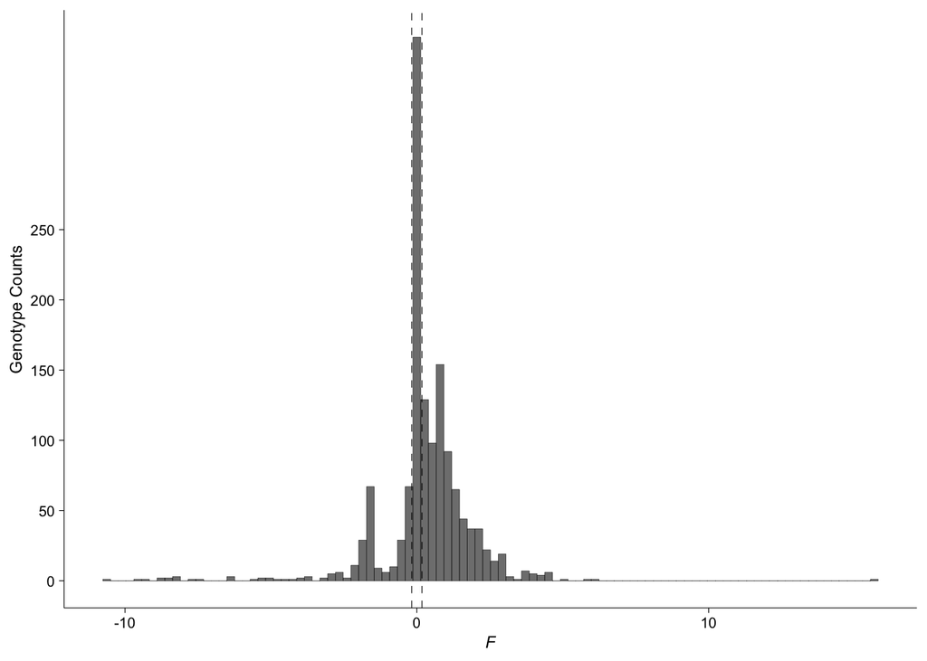

```r
fit_land_plot = fit_land %>%
  ggplot(aes(x = effect)) +
  geom_histogram(bins = 100, alpha = 0.8, color = "black", lwd = 0.1) +
  geom_vline(xintercept = log10(1.5), lty = 2, lwd = 0.2) +
  geom_vline(xintercept = log10(1/1.5), lty = 2, lwd = 0.2) +
  theme_classic() +
  labs(x = expression(italic("F")),
       y = "Genotype Counts") +
  scale_y_continuous(breaks = c(0, 50, 100, 150, 200, 250)) +
  theme(axis.line = element_line(size = 0.2, color = "black"), axis.ticks = element_line(size = 0.2, color = "black"), text = element_text(size = 9), axis.text = element_text(size = 8, color = "black"))
fit_land_plot
```

```r
#ggsave("supp_fig_1.svg", plot = fit_land_plot, width = 180/2, height = 247/4, dpi = 300, units = "mm")
```

## Ratio Data

First we import the ratio datasets, which contains ratio values between predicted function based on the additive model vs observed function. These ratio values serve as a general metric for “epistasis” as defined by the additive model.

```r
all_ratios = lapply(paste0("trans_Output/", list.files(path = "trans_Output", pattern="ratio_export.csv", recursive = T)), read_csv, skip = 1, show_col_types=F, col_names = c("id", "effect", "muts", "cv", "colors"))

all_ratios_id = str_remove_all(list.files(path = "trans_Output", pattern="ratio_export.csv", recursive = T), "/ratio_export.csv")

temp_col_length = length(all_ratios[[1]]) + 1

for(i in 1:length(all_ratios)) {
  all_ratios[[i]][, temp_col_length] = rep(all_ratios_id[i], dim(all_ratios[[i]])[1]) ## Add partial_id as a column to each ratio df in list
}

rm(temp_col_length)

## Make into a tibble
all_ratios = do.call("rbind", all_ratios)
colnames(all_ratios) = c("id", "effect", "muts", "cv", "colors", "partial_id")
```

Filtering ratio data to only include genotypes with 2+ mutations. Outputting length of vector.

```r
all_ratios = all_ratios %>% filter(muts > 1)

length(all_ratios$effect) # examined muts
```

```
## [1] 1201
```

Number and % of synergystic genotypes (i.e. ratio > 1.5-fold)

```r
sum(all_ratios$effect > 1.5) # synergystic
```

```
## [1] 411
```

```r
paste0("Synergystic ", round(sum(all_ratios$effect > 1.5)/length(all_ratios$effect)*100,2), "%", collapse = "") # synergystic %
```

```
## [1] "Synergystic 34.22%"
```

```r
sum(all_ratios$effect >= 1/1.5 & all_ratios$effect <= 1.5) # antagonistic
```

```
## [1] 466
```

```r
paste0("Neutral ", round(sum(all_ratios$effect >= 1/1.5 & all_ratios$effect <= 1.5)/length(all_ratios$effect)*100, 2), "%", collapse = "") # antagonistic %
```

```
## [1] "Neutral 38.8%"
```

```r
sum(all_ratios$effect < 1/1.5) # antagonistic
```

```
## [1] 324
```

```r
paste0("Antagonistic ", round(sum(all_ratios$effect < 1/1.5)/length(all_ratios$effect)*100, 2), "%", collapse = "") # antagonistic %
```

```
## [1] "Antagonistic 26.98%"
```

### Histogram

Shows distribution of positive and negative epistasis across the landscapes. The significance threshold is 1.5-fold

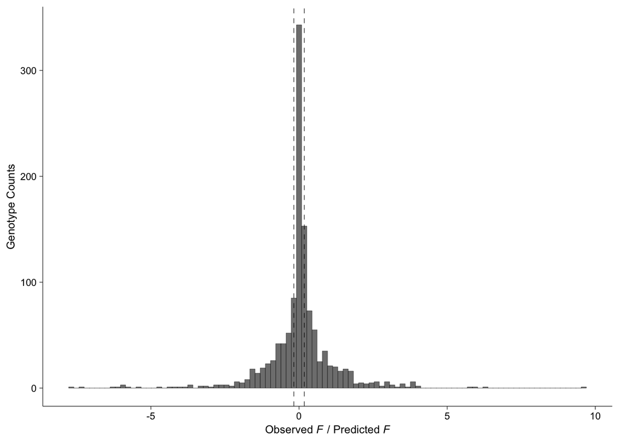

```r
all_ratios_plot = all_ratios %>%
  ggplot(aes(x = log10(effect))) +
  geom_histogram(bins = 100, alpha = 0.8, color = "black", lwd = 0.1) +
  geom_vline(xintercept = log10(1.5), lty = 2, lwd = 0.2) +
  geom_vline(xintercept = log10(1/1.5), lty = 2, lwd = 0.2) +
  theme_classic() +
  scale_fill_manual(values = c("grey")) +
  labs(x = expression("Observed" *italic(" F")*" / Predicted"*italic(" F")),
       y = "Genotype Counts") +
  theme(axis.line = element_line(size = 0.2, color = "black"), axis.ticks = element_line(size = 0.2, color = "black"), text = element_text(size = 9), axis.text = element_text(size = 8, color = "black"), legend.position = "none")


all_ratios_plot
```

```r
#ggsave("supp_fig_2.svg", plot = all_ratios_plot, width = 180/2, height = 247/4, dpi = 300, units = "mm")
```

Also the ratios table. Here we create bins from -Inf to log10(1/1.5), i.e. -0.176, then the neutral range between log10(1/1.5) to log10(1.5), i.e. 0.176, then the positive range from 0.176 to Inf.

```r
all_ratios %>%
  mutate(sign = cut(log10(effect), breaks = c(-Inf, log10(1/1.5), log10(1.5), Inf))) %>%
  count(sign) %>%
  mutate(percent = round(n/sum(n) * 100, 2))
```

```
## # A tibble: 3 × 3
##   sign               n percent
##   <fct>          <int>   <dbl>
## 1 (-Inf,-0.176]    324    27.0
## 2 (-0.176,0.176]   466    38.8
## 3 (0.176, Inf]     411    34.2
```

We can do the same thing for individual orders: 2nd, 3rd, and 4th order

### 2nd order

```r
## 2nd step only

all_ratios_2 = all_ratios %>% filter(muts == 2)

length(all_ratios_2$effect) # examined muts
```

```
## [1] 395
```

```r
sum(all_ratios_2$effect > 1.5) # synergystic
```

```
## [1] 105
```

```r
paste0("Synergystic ", round(sum(all_ratios_2$effect > 1.5)/length(all_ratios_2$effect)*100, 2), "%", collapse = "") # synergystic %
```

```
## [1] "Synergystic 26.58%"
```

```r
sum(all_ratios_2$effect >= 1/1.5 & all_ratios_2$effect <= 1.5) # antagonistic
```

```
## [1] 197
```

```r
paste0("Neutral ", round(sum(all_ratios_2$effect >= 1/1.5 & all_ratios_2$effect <= 1.5)/length(all_ratios_2$effect)*100, 2), "%", collapse = "") # antagonistic %
```

```
## [1] "Neutral 49.87%"
```

```r
sum(all_ratios_2$effect < 1/1.5) # antagonistic
```

```
## [1] 93
```

```r
paste0("Antagonistic ", round(sum(all_ratios_2$effect < 1/1.5)/length(all_ratios_2$effect)*100, 2), "%", collapse = "") # antagonistic %
```

```
## [1] "Antagonistic 23.54%"
```

### 3rd order

```r
## 3rd step only

all_ratios_3 = all_ratios %>% filter(muts == 3)

length(all_ratios_3$effect) # examined muts
```

```
## [1] 422
```

```r
sum(all_ratios_3$effect > 1.5) # synergystic
```

```
## [1] 122
```

```r
paste0("Synergystic ", round(sum(all_ratios_3$effect > 1.5)/length(all_ratios_3$effect)*100, 2), "%", collapse = "") # synergystic %
```

```
## [1] "Synergystic 28.91%"
```

```r
sum(all_ratios_3$effect >= 1/1.5 & all_ratios_3$effect <= 1.5) # antagonistic
```

```
## [1] 155
```

```r
paste0("Neutral ", round(sum(all_ratios_3$effect >= 1/1.5 & all_ratios_3$effect <= 1.5)/length(all_ratios_3$effect)*100, 2), "%", collapse = "") # antagonistic %
```

```
## [1] "Neutral 36.73%"
```

```r
sum(all_ratios_3$effect < 1/1.5) # antagonistic
```

```
## [1] 145
```

```r
paste0("Antagonistic ", round(sum(all_ratios_3$effect < 1/1.5)/length(all_ratios_3$effect)*100, 2), "%", collapse = "") # antagonistic %
```

```
## [1] "Antagonistic 34.36%"
```

### 4th order

```r
## 4th step only

all_ratios_4 = all_ratios %>% filter(muts == 4)

length(all_ratios_4$effect) # examined muts
```

```
## [1] 263
```

```r
sum(all_ratios_4$effect > 1.5) # synergystic
```

```
## [1] 110
```

```r
paste0("Synergystic ", round(sum(all_ratios_4$effect > 1.5)/length(all_ratios_4$effect)*100, 2), "%", collapse = "") # synergystic %
```

```
## [1] "Synergystic 41.83%"
```

```r
sum(all_ratios_4$effect >= 1/1.5 & all_ratios_4$effect <= 1.5) # antagonistic
```

```
## [1] 83
```

```r
paste0("Neutral ", round(sum(all_ratios_4$effect >= 1/1.5 & all_ratios_4$effect <= 1.5)/length(all_ratios_4$effect)*100, 2), "%", collapse = "") # antagonistic %
```

```
## [1] "Neutral 31.56%"
```

```r
sum(all_ratios_4$effect < 1/1.5) # antagonistic
```

```
## [1] 70
```

```r
paste0("Antagonistic ", round(sum(all_ratios_4$effect < 1/1.5)/length(all_ratios_4$effect)*100, 2), "%", collapse = "") # antagonistic %
```

```
## [1] "Antagonistic 26.62%"
```

## Positional Functional Contribution Data

Here we import the functional contribution of single positions (not combinations), which resembles first order analysis across all datasets.

```r
## Reads all csvs in collated folder and combines them

d = do.call("rbind", lapply(paste0("trans_Output/", list.files(path = "trans_Output", pattern="*2d_box.csv", recursive = T)), read_csv, show_col_types=F, col_names = c("positions", "identity", "mut", "effects", "enzyme", "type", "cond")))


d1 = d %>% filter_all(any_vars(!is.na(.))) # removes rows with all NA before making unique ID

d1 = d1 %>%
  unite("unique_id", c(positions, enzyme, type, cond), remove = F)

d1 = d1 %>%
  unite("partial_id", c(enzyme, type, cond), remove = F)
```

### Histogram

Spread of functional contributions of the positions. This shows whether introducing a mutation in a given position impacts the function positively or negatively (or neutral) across all backgrounds

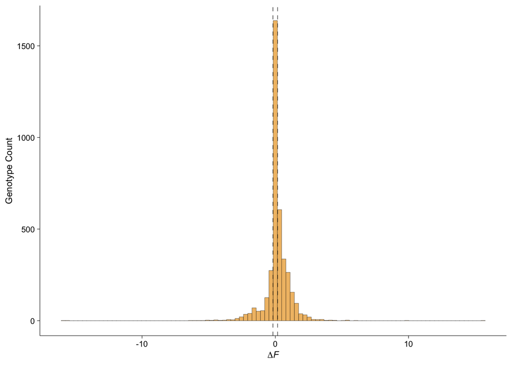

```r
d1_plot = d1 %>%
  ggplot(aes(x = effects)) +
  geom_histogram(bins = 100, alpha = 0.8, color = "black", lwd = 0.1, fill = "#edae49") +
  geom_vline(xintercept = log10(1.5), lty = 2, lwd = 0.2) +
  geom_vline(xintercept = log10(1/1.5), lty = 2, lwd = 0.2) +
  theme_classic() +
  labs(x = expression(Delta*italic("F")),
       y = "Genotype Count") +
  theme(axis.line = element_line(size = 0.2, color = "black"), axis.ticks = element_line(size = 0.2, color = "black"), text = element_text(size = 9), axis.text = element_text(size = 8, color = "black"), legend.position = "none")


d1_plot
```

```r
#ggsave("fig_1A.svg", plot = d1_plot, width = 180/2, height = 247/4, dpi = 300, units = "mm")
```

What are the percentages of each in the categories?

```r
d1 %>%
  count(effects < log10(1/1.5),
        effects > log10(1.5)) %>%
  mutate(prop = n/sum(n)*100)
```

```
## # A tibble: 3 × 4
##   `effects < log10(1/1.5)` `effects > log10(1.5)`     n  prop
##   <lgl>                    <lgl>                  <int> <dbl>
## 1 FALSE                    FALSE                   1723  43.8
## 2 FALSE                    TRUE                    1523  38.7
## 3 TRUE                     FALSE                    690  17.5
```

Density plots for each trajectory by enzymes

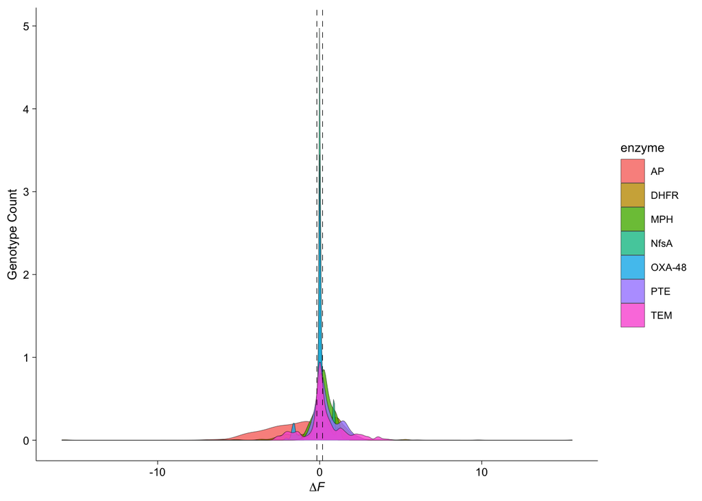

```r
d1_plot_enz = d1 %>%
  ggplot(aes(x = effects, fill = enzyme)) +
  geom_density(alpha = 0.8, color = "black", lwd = 0.1) +
  geom_vline(xintercept = log10(1.5), lty = 2, lwd = 0.2) +
  geom_vline(xintercept = log10(1/1.5), lty = 2, lwd = 0.2) +
  theme_classic() +
  labs(x = expression(Delta*italic("F")),
       y = "Genotype Count") +
  #scale_y_continuous(breaks = c(0, 50, 100, 150, 200, 250)) +
  theme(axis.line = element_line(size = 0.2, color = "black"), axis.ticks = element_line(size = 0.2, color = "black"), text = element_text(size = 9), axis.text = element_text(size = 8, color = "black"))


d1_plot_enz
```

### For WT-normalized data

Load the same kind of data as d1 except that has been normalized do the $\Delta$F in the WT background

```r
wt_rel_df = do.call("rbind", lapply(paste0("trans_Output/", list.files(path = "trans_Output", pattern="*wt_rel.csv", recursive = T)), read_csv, show_col_types=F, col_names = c("positions", "identity", "mut", "effects", "enzyme", "type", "cond")))


wt_rel_df = wt_rel_df %>% filter_all(any_vars(!is.na(.))) # removes rows with all NA before making unique ID

wt_rel_df = wt_rel_df %>%
  unite("unique_id", c(positions, enzyme, type, cond), remove = F) %>%
  unite("partial_id", c(enzyme, type, cond), remove = F)
```

Then we plot it

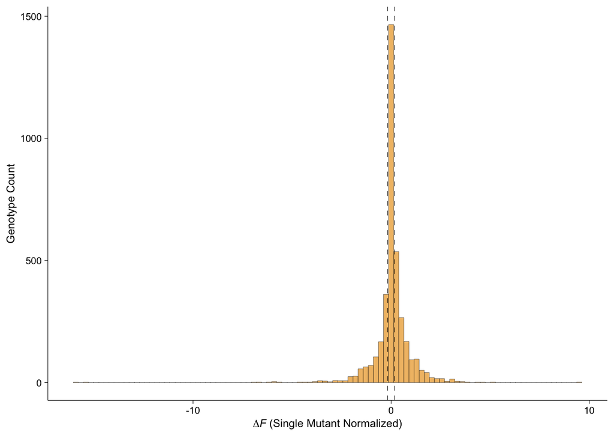

```r
wt_rel_plot = wt_rel_df %>%
  filter(mut > 1) %>% # filter out first mutations which are by definition 0 delta F
  ggplot(aes(x = effects)) +
  geom_histogram(bins = 100, alpha = 0.8, color = "black", lwd = 0.1, fill = "#edae49") +
  geom_vline(xintercept = log10(1.5), lty = 2, lwd = 0.2) +
  geom_vline(xintercept = log10(1/1.5), lty = 2, lwd = 0.2) +
  theme_classic() +
  labs(x = expression(Delta*italic("F ")*"(Single Mutant Normalized)"),
       y = "Genotype Count") +
  theme(axis.line = element_line(size = 0.2, color = "black"), axis.ticks = element_line(size = 0.2, color = "black"), text = element_text(size = 9), axis.text = element_text(size = 8, color = "black"), legend.position = "none")


wt_rel_plot
```

```r
#ggsave("fig_1A.svg", plot = d1_plot, width = 180/2, height = 247/4, dpi = 300, units = "mm")
```

And again for density plots for each enzyme

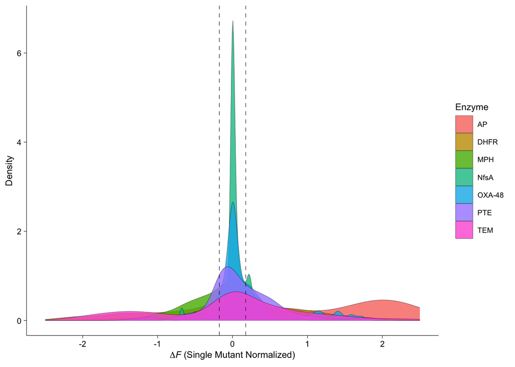

```r
wt_rel_plot_enz = wt_rel_df %>%
  mutate(Enzyme = enzyme) %>%
  filter(mut > 1) %>%
  ggplot(aes(x = effects, fill = Enzyme)) +
  geom_density(alpha = 0.8, color = "black", lwd = 0.1) +
  geom_vline(xintercept = log10(1.5), lty = 2, lwd = 0.2) +
  geom_vline(xintercept = log10(1/1.5), lty = 2, lwd = 0.2) +
  theme_classic() +
  labs(x = expression(Delta*italic("F ")*"(Single Mutant Normalized)"),
       y = "Density") +
  scale_x_continuous(limits = c(-2.5, 2.5)) + # Same data omitted for better resolution
  theme(axis.line = element_line(size = 0.2, color = "black"), axis.ticks = element_line(size = 0.2, color = "black"), text = element_text(size = 9), axis.text = element_text(size = 8, color = "black"))


wt_rel_plot_enz
```

Given this spread which percentage is significantly (using log10 1.5-fold cutoff) **negative**, **neutral**, and **positive** in that order

```r
wt_rel_df %>%
  filter(mut > 1) %>%
  mutate(sign = cut(effects, breaks = c(-Inf, log10(1/1.5), log10(1.5), Inf))) %>%
  count(sign) %>%
  mutate(percent = round(n/sum(n) * 100, 2))
```

```
## # A tibble: 3 × 3
##   sign               n percent
##   <fct>          <int>   <dbl>
## 1 (-Inf,-0.176]    825    22.1
## 2 (-0.176,0.176]  1693    45.3
## 3 (0.176, Inf]    1220    32.6
```

## Heterogenity in Spread

Looks at 2*SD of each position/combination across all orders to determine functional heterogeneity.

This gives us a quick look at the general spread of heterogenity values and their mean.

```r
idio_d = do.call("rbind", lapply(paste0("trans_Output/", list.files(path = "trans_Output", pattern="idio_df", recursive = T)), read_csv, show_col_types=F))

traj_col = sapply(str_split(list.files(path = "trans_Output", pattern="idio_df", recursive = T), "/"),"[[",1)

traj_col_len = sapply(lapply(paste0("trans_Output/", list.files(path = "trans_Output", pattern="idio_df", recursive = T)), read_csv, show_col_types=F), dim)[1,]

traj_col_full = c()
for(i in 1:length(traj_col)) {
  traj_col_full = c(traj_col_full, rep(traj_col[i], traj_col_len[i]))
}

idio_d$traj = traj_col_full
```

### Order 1

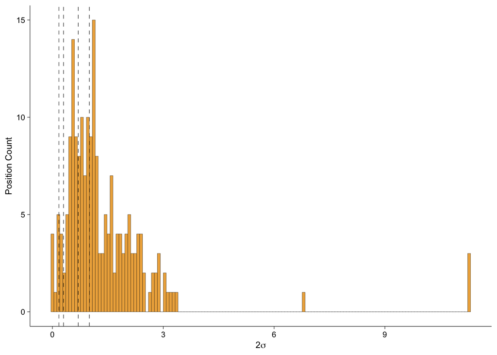

```r
idio_d_order_1 = idio_d %>%
  filter(mutations == "Order 1") %>%
  ggplot(aes(x = idiosync)) +
  geom_histogram(binwidth = 0.08, color = "black", lwd = 0.1, fill = "#edae49") +
  geom_vline(xintercept = log10(1.5), lty = 2, lwd = 0.2) +
  geom_vline(xintercept = log10(2), lty = 2, lwd = 0.2) +
  geom_vline(xintercept = log10(5), lty = 2, lwd = 0.2) +
  geom_vline(xintercept = log10(10), lty = 2, lwd = 0.2) +
  labs(x = expression("2"*sigma),
       y = "Position Count") +
  theme_classic() +
  theme(axis.line = element_line(size = 0.2, color = "black"), axis.ticks = element_line(size = 0.2, color = "black"), text = element_text(size = 9), axis.text = element_text(size = 8, color = "black"), legend.position = "none")

idio_d_order_1
```

```r
#ggsave("fig_1B.svg", idio_d_order_1, width = 180/2, height = 247/4, dpi = 300, units = "mm")
```

First order positions which have a heterogeneity index > log10 1.5-fold, 2-fold, 5-fold, and 10-fold for adaptive trajectories

```r
idio_d %>%
  filter(mutations == "Order 1") %>%
  mutate(idiosync_1.5 = idiosync > log10(1.5),
         idiosync_2 = idiosync > log10(2),
         idiosync_5 = idiosync > log10(5),
         idiosync_10 = idiosync > log10(10)) %>%
  group_by(mutations) %>%
  summarise(idiosync_sig_1.5 = sum(idiosync_1.5),
            idiosync_sig_2 = sum(idiosync_2),
            idiosync_sig_5 = sum(idiosync_5),
            idiosync_sig_10 = sum(idiosync_10),
            idiosync_total = length(idiosync),
            idiosync_1.5 = sum(idiosync_1.5)/length(idiosync_1.5) * 100,
            idiosync_2 = sum(idiosync_2)/length(idiosync_2) * 100,
            idiosync_5 = sum(idiosync_5)/length(idiosync_5) * 100,
            idiosync_10 = sum(idiosync_10)/length(idiosync_10) * 100
            ) %>%
  knitr::kable()
```

| mutations | idiosync_sig_1.5 | idiosync_sig_2 | idiosync_sig_5 | idiosync_sig_10 | idiosync_total | idiosync_1.5 | idiosync_2 | idiosync_5 | idiosync_10 |
| --- | --- | --- | --- | --- | --- | --- | --- | --- | --- |
| Order 1 | 189 | 184 | 141 | 110 | 198 | 95.45455 | 92.92929 | 71.21212 | 55.55556 |

### Order 2-4

Histogram to show heterogenity at Orders 2, 3, and 4 with the log10 1.5-fold significance threshold

## Order 2

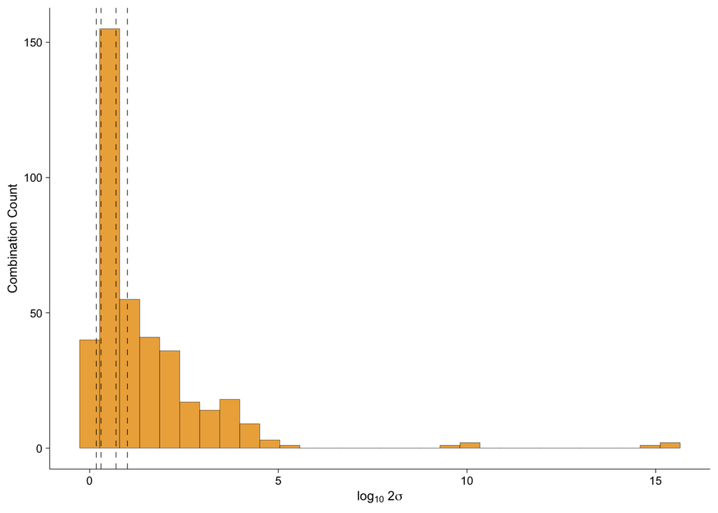

```r
idio_d_plot_2 = idio_d %>%
  filter(mutations == "Order 2") %>%
  ggplot(aes(x = idiosync)) +
  geom_histogram(fill = "#edae49", color = "black", lwd = 0.1) +
  geom_vline(xintercept = log10(1.5), lty = 2, lwd = 0.2) +
  geom_vline(xintercept = log10(2), lty = 2, lwd = 0.2) +
  geom_vline(xintercept = log10(5), lty = 2, lwd = 0.2) +
  geom_vline(xintercept = log10(10), lty = 2, lwd = 0.2) +
  labs(x = expression("log"[10]*" 2"*sigma),
       y = "Combination Count") +
  theme_classic() +
  theme(axis.line = element_line(size = 0.2, color = "black"), axis.ticks = element_line(size = 0.2, color = "black"), text = element_text(size = 9), axis.text = element_text(size = 8, color = "black"), legend.position = "none")

idio_d_plot_2
```

```r
#ggsave("fig_2A_1.svg", idio_d_plot_2, width = 180/3, height = 247/4, dpi = 300, units = "mm")
```

## Order 3

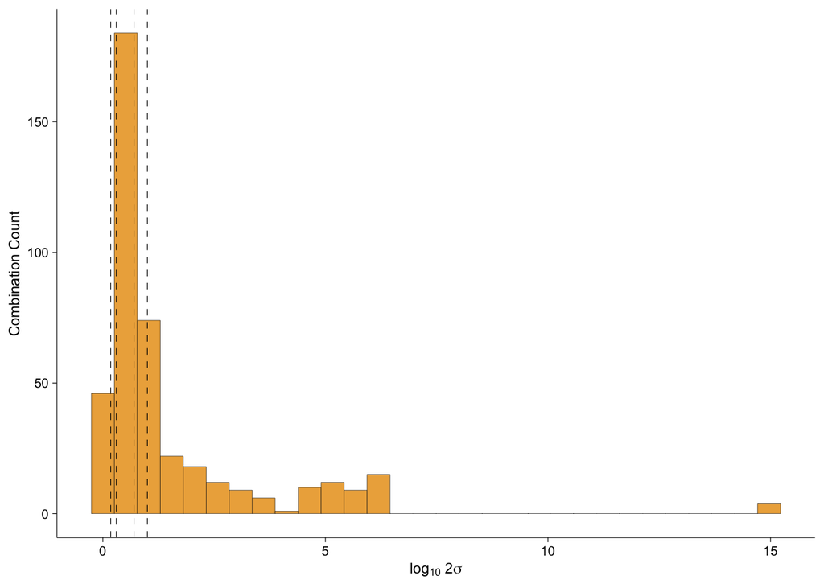

```r
idio_d_plot_3 = idio_d %>%
  filter(mutations == "Order 3") %>%
  ggplot(aes(x = idiosync)) +
  geom_histogram(fill = "#edae49", color = "black", lwd = 0.1) +
  geom_vline(xintercept = log10(1.5), lty = 2, lwd = 0.2) +
  geom_vline(xintercept = log10(2), lty = 2, lwd = 0.2) +
  geom_vline(xintercept = log10(5), lty = 2, lwd = 0.2) +
  geom_vline(xintercept = log10(10), lty = 2, lwd = 0.2) +
  labs(x = expression("log"[10]*" 2"*sigma),
       y = "Combination Count") +
  theme_classic() +
  theme(axis.line = element_line(size = 0.2, color = "black"), axis.ticks = element_line(size = 0.2, color = "black"), text = element_text(size = 9), axis.text = element_text(size = 8, color = "black"), legend.position = "none")

idio_d_plot_3
```

```r
#ggsave("fig_2A_2.svg", idio_d_plot_3, width = 180/3, height = 247/4, dpi = 300, units = "mm")
```

## Order 4

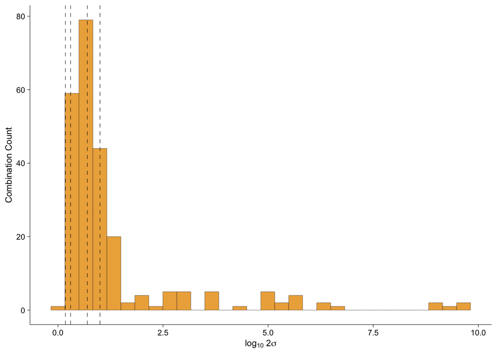

```r
idio_d_plot_4 = idio_d %>%
  filter(mutations == "Order 4") %>%
  ggplot(aes(x = idiosync)) +
  geom_histogram(fill = "#edae49", color = "black", lwd = 0.1) +
  geom_vline(xintercept = log10(1.5), lty = 2, lwd = 0.2) +
  geom_vline(xintercept = log10(2), lty = 2, lwd = 0.2) +
  geom_vline(xintercept = log10(5), lty = 2, lwd = 0.2) +
  geom_vline(xintercept = log10(10), lty = 2, lwd = 0.2) +
  labs(x = expression("log"[10]*" 2"*sigma),
       y = "Combination Count") +
  theme_classic() +
  theme(axis.line = element_line(size = 0.2, color = "black"), axis.ticks = element_line(size = 0.2, color = "black"), text = element_text(size = 9), axis.text = element_text(size = 8, color = "black"), legend.position = "none")

idio_d_plot_4
```

```r
#ggsave("fig_2A_3.svg", idio_d_plot_4, width = 180/3, height = 247/4, dpi = 300, units = "mm")
```

## Order 2-4 in Facet Grid

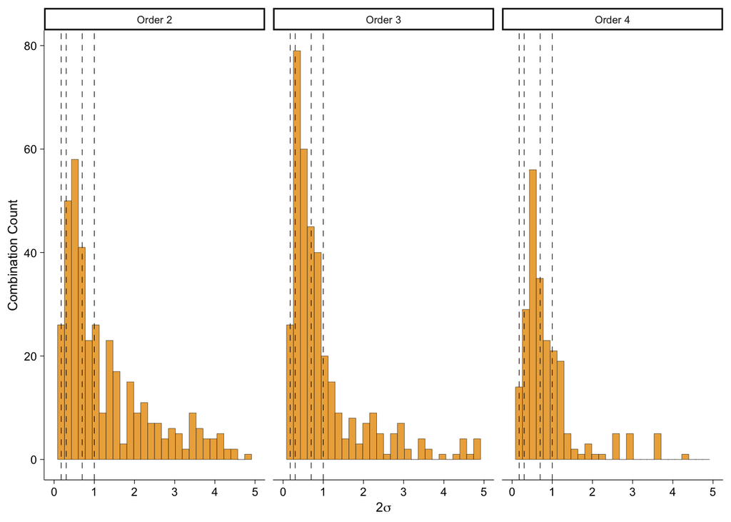

```r
idio_d_multi_plot = idio_d %>%
  filter(mutations != "Order 1" & mutations != "Order 5" & mutations != "Order 6") %>%
  ggplot(aes(x = idiosync)) +
  geom_histogram(color = "black", lwd = 0.1, fill = "#edae49") +
  geom_vline(xintercept = log10(1.5), lty = 2, lwd = 0.2) +
  geom_vline(xintercept = log10(2), lty = 2, lwd = 0.2) +
  geom_vline(xintercept = log10(5), lty = 2, lwd = 0.2) +
  geom_vline(xintercept = log10(10), lty = 2, lwd = 0.2) +
  labs(x = expression("2"*sigma),
       y = "Combination Count") +
  facet_grid(~ mutations) +
  scale_x_continuous(limits = c(0,5)) +
  theme_classic() +
  theme(axis.line = element_line(size = 0.2, color = "black"), axis.ticks = element_line(size = 0.2, color = "black"), text = element_text(size = 9), axis.text = element_text(size = 8, color = "black"), legend.position = "none")

idio_d_multi_plot # Data removed
```

```r
#ggsave("fig_2A.svg", idio_d_multi_plot, width = 180, height = 247/4, dpi = 300, units = "mm")
```

What percentage of positions remain significantly heterogeneous (1.5-fold) at these orders?

```r
idio_d %>%
  filter(mutations == "Order 2" | mutations == "Order 3" | mutations == "Order 4") %>%
  mutate(idiosync = idiosync > log10(1.5)) %>%
  group_by(mutations) %>%
  summarise(idiosync_sig = sum(idiosync),
            idiosync_total = length(idiosync),
            idiosync = sum(idiosync)/length(idiosync) * 100
            )
```

```
## # A tibble: 3 × 4
##   mutations idiosync_sig idiosync_total idiosync
##   <chr>            <int>          <int>    <dbl>
## 1 Order 2            376            395     95.2
## 2 Order 3            397            422     94.1
## 3 Order 4            244            245     99.6
```

What percentage of positions remain significantly heterogeneous (1.5-, 2-, 5-, and 10-fold) at all orders?

```r
idio_d %>%
  filter(mutations == "Order 1" | mutations == "Order 2" | mutations == "Order 3" | mutations == "Order 4") %>%
  mutate(idiosync_1.5 = idiosync > log10(1.5),
         idiosync_2 = idiosync > log10(2),
         idiosync_5 = idiosync > log10(5),
         idiosync_10 = idiosync > log10(10)) %>%
  group_by(mutations) %>%
  summarise(idiosync_sig_1.5 = sum(idiosync_1.5),
            idiosync_sig_2 = sum(idiosync_2),
            idiosync_sig_5 = sum(idiosync_5),
            idiosync_sig_10 = sum(idiosync_10),
            idiosync_total = length(idiosync),
            idiosync_1.5 = sum(idiosync_1.5)/length(idiosync_1.5) * 100,
            idiosync_2 = sum(idiosync_2)/length(idiosync_2) * 100,
            idiosync_5 = sum(idiosync_5)/length(idiosync_5) * 100,
            idiosync_10 = sum(idiosync_10)/length(idiosync_10) * 100
            ) %>%
  knitr::kable()
```

| mutations | idiosync_sig_1.5 | idiosync_sig_2 | idiosync_sig_5 | idiosync_sig_10 | idiosync_total | idiosync_1.5 | idiosync_2 | idiosync_5 | idiosync_10 |
| --- | --- | --- | --- | --- | --- | --- | --- | --- | --- |
| Order 1 | 189 | 184 | 141 | 110 | 198 | 95.45455 | 92.92929 | 71.21212 | 55.55556 |
| Order 2 | 376 | 351 | 229 | 172 | 395 | 95.18987 | 88.86076 | 57.97468 | 43.54430 |
| Order 3 | 397 | 359 | 206 | 147 | 422 | 94.07583 | 85.07109 | 48.81517 | 34.83412 |
| Order 4 | 244 | 225 | 123 | 79 | 245 | 99.59184 | 91.83673 | 50.20408 | 32.24490 |

## Heterogenity in Sign

Collects all $\Delta$Function data for all orders

```r
higher_order_list = list.files(path = "trans_Output", pattern="higher_box", recursive = T)

higher_df = data.frame()
for(higher_file in 1:length(higher_order_list)){
  Condition = str_split(str_split(higher_order_list[higher_file], "_")[[1]][3], "/")[[1]][1]
  Measurement = str_split(higher_order_list[higher_file], "_")[[1]][2]
  Enzyme = str_split(higher_order_list[higher_file], "_")[[1]][1]
  appending_file = read_csv(paste0("trans_Output/", higher_order_list[higher_file]), show_col_types=F)
  appending_file$Condition = Condition
  appending_file$Measurement = Measurement
  appending_file$Enzyme = Enzyme
  higher_df = bind_rows(higher_df, appending_file)
}


higher_df = higher_df %>%
  unite("unique_id", c(pos, Condition, Measurement, Enzyme), remove = F) %>%
  unite("partial_id", c(Enzyme, Measurement, Condition), remove = F)

higher_all_sign_check = higher_df %>%
  filter(str_count(genotype, "x")/str_length(genotype) != 1) %>% # Remove interactions with no other backgrounds
  mutate(mutations = factor(paste("Order", mutations, sep = " "))) %>%
  group_by(unique_id, mutations) %>%
  summarise(min_effect = min(avg),
            max_effect = max(avg))
```

Assigning positive, neutral, negative, negative-neutral, positive-neutral, and negative-positive ‘types’ based on log10 1.5-fold threshold to every Order

```r
threshold = 1.5

types = c()
for(each in 1:dim(higher_all_sign_check)[1]){
  if(higher_all_sign_check$min_effect[each] < log10(1/threshold)){
    # Negative branch
    if(higher_all_sign_check$max_effect[each] < log10(1/threshold)) {
      # Full negative
      types = c(types, "Negative")
    } else if(higher_all_sign_check$max_effect[each] <= log10(threshold)) {
      # Negative Neutral
      types = c(types, "Neutral Negative")
    } else {
      # Negative Positive
      types = c(types, "Positive Negative")
    }
  } else {
    # Neutral or Positive
    if(higher_all_sign_check$min_effect[each] > log10(threshold)) {
      # Full positive
      types = c(types, "Positive")
    } else if(higher_all_sign_check$max_effect[each] > log10(threshold)) {
      # Neutral Positive
      types = c(types, "Neutral Positive")
    } else {
      # Neutral
      types = c(types, "Neutral")
    }
  }
}

higher_all_sign_check$type = factor(types)
```

All outputs show position/combination numbers in each category, followed by the total sum of all probed positions/combinations at that order, and finally percentages of each category

### Order 1

```r
order_checker = higher_all_sign_check %>%
  filter(mutations == "Order 1") %>%
  pull(type)

order_checker_levels = c("Negative", "Neutral", "Positive", "Neutral Negative", "Neutral Positive", "Positive Negative")

summary(order_checker)
```

```
##          Negative           Neutral  Neutral Negative  Neutral Positive
##                 3                 5                34                44
##          Positive Positive Negative
##                20                92
```

```r
sum(summary(order_checker))
```

```
## [1] 198
```

```r
summary(order_checker) / length(order_checker) * 100
```

```
##          Negative           Neutral  Neutral Negative  Neutral Positive
##          1.515152          2.525253         17.171717         22.222222
##          Positive Positive Negative
##         10.101010         46.464646
```

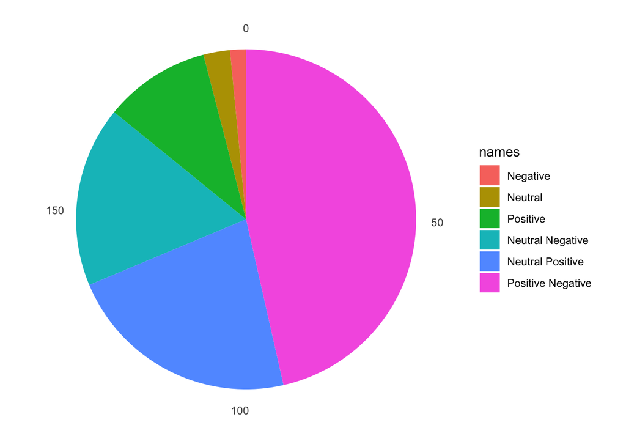

```r
pie_df = tibble(names = factor(names(summary(order_checker)), levels = order_checker_levels), values = summary(order_checker))

pie_order_1 = ggplot(pie_df, aes(x="", y=values, fill=names))+
  geom_bar(width = 1, stat = "identity") +
  coord_polar("y") +
  theme_minimal() +
  theme(axis.title.x = element_blank(), axis.title.y = element_blank(), panel.border = element_blank(), panel.grid=element_blank(), axis.ticks = element_blank(), plot.title=element_text(size=14, face="bold"))

pie_order_1
```

```r
#ggsave("fig_1C.svg", pie_order_1, width = 180/2, height = 247/4, dpi = 300, units = "mm")
```

### Order 2

```r
order_checker = higher_all_sign_check %>%
  filter(mutations == "Order 2") %>%
  pull(type)

summary(order_checker)
```

```
##          Negative           Neutral  Neutral Negative  Neutral Positive
##                 3                11                44                68
##          Positive Positive Negative
##                10               259
```

```r
sum(summary(order_checker))
```

```
## [1] 395
```

```r
summary(order_checker) / length(order_checker) * 100
```

```
##          Negative           Neutral  Neutral Negative  Neutral Positive
##         0.7594937         2.7848101        11.1392405        17.2151899
##          Positive Positive Negative
##         2.5316456        65.5696203
```

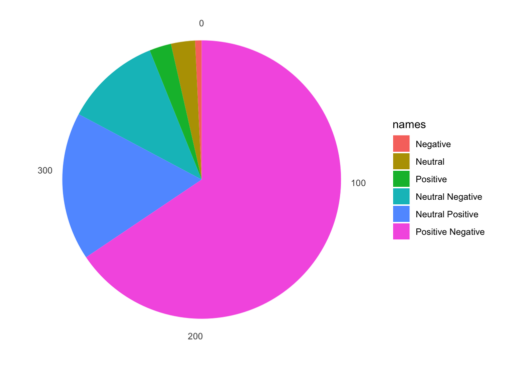

```r
pie_df = tibble(names = factor(names(summary(order_checker)), levels = order_checker_levels), values = summary(order_checker))

pie_order_2 = ggplot(pie_df, aes(x="", y=values, fill=names))+
  geom_bar(width = 1, stat = "identity") +
  coord_polar("y") +
  theme_minimal() +
  theme(axis.title.x = element_blank(), axis.title.y = element_blank(), panel.border = element_blank(), panel.grid=element_blank(), axis.ticks = element_blank(), plot.title=element_text(size=14, face="bold"))

pie_order_2
```

```r
#ggsave("fig_2B_1.svg", pie_order_2, width = 180/2, height = 247/4, dpi = 300, units = "mm")
```

### Order 3

```r
order_checker = higher_all_sign_check %>%
  filter(mutations == "Order 3") %>%
  pull(type)

summary(order_checker)
```

```
##          Negative           Neutral  Neutral Negative  Neutral Positive
##                12                13                51                58
##          Positive Positive Negative
##                37               251
```

```r
sum(summary(order_checker))
```

```
## [1] 422
```

```r
summary(order_checker) / length(order_checker) * 100
```

```
##          Negative           Neutral  Neutral Negative  Neutral Positive
##          2.843602          3.080569         12.085308         13.744076
##          Positive Positive Negative
##          8.767773         59.478673
```

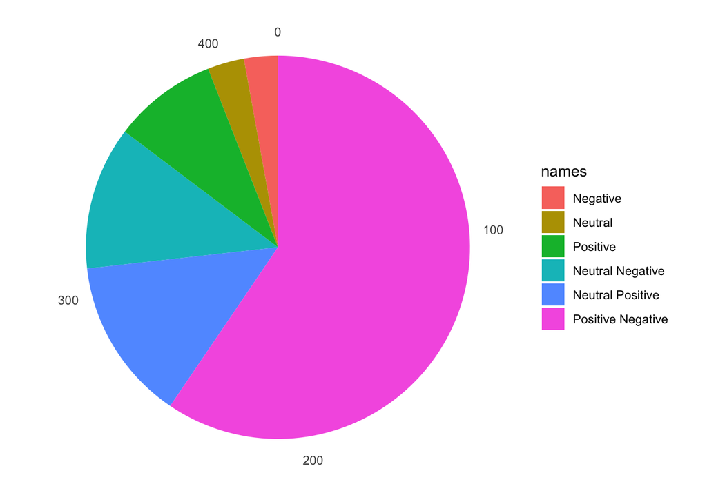

```r
pie_df = tibble(names = factor(names(summary(order_checker)), levels = order_checker_levels), values = summary(order_checker))

pie_order_3 = ggplot(pie_df, aes(x="", y=values, fill=names))+
  geom_bar(width = 1, stat = "identity") +
  coord_polar("y") +
  theme_minimal() +
  theme(axis.title.x = element_blank(), axis.title.y = element_blank(), panel.border = element_blank(), panel.grid=element_blank(), axis.ticks = element_blank(), plot.title=element_text(size=14, face="bold"))

pie_order_3
```

```r
#ggsave("fig_2B_2.svg", pie_order_3, width = 180/2, height = 247/4, dpi = 300, units = "mm")
```

### Order 4

```r
order_checker = higher_all_sign_check %>%
  filter(mutations == "Order 4") %>%
  pull(type)

summary(order_checker)
```

```
##          Negative           Neutral  Neutral Negative  Neutral Positive
##                14                 3                47                38
##          Positive Positive Negative
##                 8               135
```

```r
sum(summary(order_checker))
```

```
## [1] 245
```

```r
summary(order_checker) / length(order_checker) * 100
```

```
##          Negative           Neutral  Neutral Negative  Neutral Positive
##          5.714286          1.224490         19.183673         15.510204
##          Positive Positive Negative
##          3.265306         55.102041
```

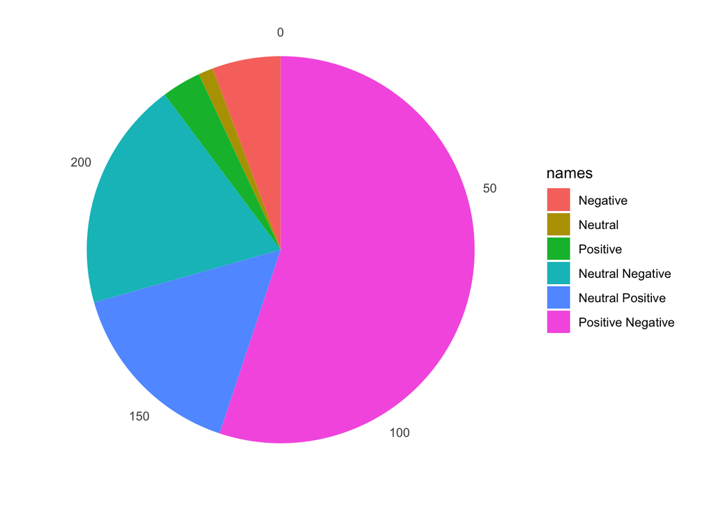

```r
pie_df = tibble(names = factor(names(summary(order_checker)), levels = order_checker_levels), values = summary(order_checker))

pie_order_4 = ggplot(pie_df, aes(x="", y=values, fill=names))+
  geom_bar(width = 1, stat = "identity") +
  coord_polar("y") +
  theme_minimal() +
  theme(axis.title.x = element_blank(), axis.title.y = element_blank(), panel.border = element_blank(), panel.grid=element_blank(), axis.ticks = element_blank(), plot.title=element_text(size=14, face="bold"))

pie_order_4
```

```r
#ggsave("fig_2B_3.svg", pie_order_4, width = 180/2, height = 247/4, dpi = 300, units = "mm")
```

### All Orders

Raw Values

```r
higher_all_sign_check_table = higher_all_sign_check %>%
  group_by(mutations) %>%
  count(type) %>%
  pivot_wider(names_from = type,
              values_from = n) %>%
  mutate(Total = sum(across("Negative":"Positive Negative")))

higher_all_sign_check_table %>% knitr::kable()
```

| mutations | Negative | Neutral | Neutral Negative | Neutral Positive | Positive | Positive Negative | Total |
| --- | --- | --- | --- | --- | --- | --- | --- |
| Order 1 | 3 | 5 | 34 | 44 | 20 | 92 | 198 |
| Order 2 | 3 | 11 | 44 | 68 | 10 | 259 | 395 |
| Order 3 | 12 | 13 | 51 | 58 | 37 | 251 | 422 |
| Order 4 | 14 | 3 | 47 | 38 | 8 | 135 | 245 |
| Order 5 | 8 | 3 | 12 | 8 | 9 | 44 | 84 |
| Order 6 | NA | NA | 3 | 5 | 1 | 5 | NA |

Percentages

```r
higher_all_sign_check_table %>%
  mutate(Negative = Negative/Total*100,
         Neutral = Neutral/Total*100,
         `Neutral Negative` = `Neutral Negative`/Total*100,
         `Neutral Positive` = `Neutral Positive`/Total*100,
         Positive = Positive/Total*100,
         `Positive Negative` = `Positive Negative`/Total*100) %>%
  knitr::kable()
```

| mutations | Negative | Neutral | Neutral Negative | Neutral Positive | Positive | Positive Negative | Total |
| --- | --- | --- | --- | --- | --- | --- | --- |
| Order 1 | 1.5151515 | 2.525253 | 17.17172 | 22.22222 | 10.101010 | 46.46465 | 198 |
| Order 2 | 0.7594937 | 2.784810 | 11.13924 | 17.21519 | 2.531646 | 65.56962 | 395 |
| Order 3 | 2.8436019 | 3.080569 | 12.08531 | 13.74408 | 8.767772 | 59.47867 | 422 |
| Order 4 | 5.7142857 | 1.224490 | 19.18367 | 15.51020 | 3.265306 | 55.10204 | 245 |
| Order 5 | 9.5238095 | 3.571429 | 14.28571 | 9.52381 | 10.714286 | 52.38095 | 84 |
| Order 6 | NA | NA | NA | NA | NA | NA | NA |

## WT points to Mean Deviation

Purpose of this analysis was to determine the difference in $\Delta$Function between the WT-background contribution of a given position/combination and the mean contribution of a given position or combination

# Histogram

The spread of all positional contribution vs mean differences for each Order (1-4)

```r
higher_df_mean = higher_df %>%
  filter(mutations < 5) %>%
  filter(str_count(genotype, "x")/str_length(genotype) != 1) %>% # Remove interactions with no other backgrounds
  group_by(unique_id, partial_id) %>%
  summarise(avg = mean(avg))

devs = c()
sign_devs = c()
cur_mutations = c()
for(i in 1:dim(higher_df_mean)[1]) {
  curr_id = higher_df_mean$unique_id[i]
  devs = c(devs, abs( (higher_df %>% filter(!str_detect(genotype, "1")) %>% filter(unique_id == curr_id) %>% pull(avg)) - (higher_df_mean$avg[i]) ))
  cur_mutations = c(cur_mutations, (higher_df %>% filter(!str_detect(genotype, "1")) %>% filter(unique_id == curr_id) %>% pull(mutations)))
  sign_devs = c(sign_devs, ifelse( (((higher_df %>% filter(!str_detect(genotype, "1")) %>% filter(unique_id == curr_id) %>% pull(avg)) > log10(1.5) & (higher_df_mean$avg[i]) < log10(1/1.5)) | ((higher_df %>% filter(!str_detect(genotype, "1")) %>% filter(unique_id == curr_id) %>% pull(avg)) < log10(1/1.5) & (higher_df_mean$avg[i]) > log10(1.5))), T, F)) ## Check if WT is positive while average is negative or vice versa
}


devs_df_wt = data.frame(devs = devs, muts = cur_mutations, sign_devs = sign_devs)

## Add unique ID if the WT deviates from mean

devs_df_wt = devs_df_wt %>%
  mutate(unique_id = higher_df_mean$unique_id[row_number()]) %>%
  mutate(partial_id = higher_df_mean$partial_id[row_number()])
```

## WT sign heterogenity for Order 1

How many WT points have sign deviation from the mean at the 1st order?

```r
paste0(length(which(devs_df_wt %>% filter(muts == 1) %>% pull(sign_devs))), "/", length(devs_df_wt %>% filter(muts == 1) %>% pull(sign_devs)))
```

```
## [1] "2/198"
```

```r
paste0(round(sum(devs_df_wt %>% filter(muts == 1) %>% pull(sign_devs)) / length(devs_df_wt %>% filter(muts == 1) %>% pull(sign_devs)) * 100, 2), "%")
```

```
## [1] "1.01%"
```

## WT sign heterogenity for Order 2

How many WT points have sign deviation from the mean at the 2nd order?

```r
paste0(length(which(devs_df_wt %>% filter(muts == 2) %>% pull(sign_devs))), "/", length(devs_df_wt %>% filter(muts == 2) %>% pull(sign_devs)))
```

```
## [1] "37/395"
```

```r
paste0(round(sum(devs_df_wt %>% filter(muts == 2) %>% pull(sign_devs)) / length(devs_df_wt %>% filter(muts == 2) %>% pull(sign_devs)) * 100, 2), "%")
```

```
## [1] "9.37%"
```

## WT sign heterogenity for Order 3

How many WT points have sign deviation from the mean at the 3rd order?

```r
paste0(length(which(devs_df_wt %>% filter(muts == 3) %>% pull(sign_devs))), "/", length(devs_df_wt %>% filter(muts == 3) %>% pull(sign_devs)))
```

```
## [1] "26/422"
```

```r
paste0(round(sum(devs_df_wt %>% filter(muts == 3) %>% pull(sign_devs)) / length(devs_df_wt %>% filter(muts == 3) %>% pull(sign_devs)) * 100, 2), "%")
```

```
## [1] "6.16%"
```

## WT sign heterogenity for Order 4

How many WT points have sign deviation from the mean at the 4th order?

```r
paste0(length(which(devs_df_wt %>% filter(muts == 4) %>% pull(sign_devs))), "/", length(devs_df_wt %>% filter(muts == 4) %>% pull(sign_devs)))
```

```
## [1] "17/245"
```

```r
paste0(round(sum(devs_df_wt %>% filter(muts == 4) %>% pull(sign_devs)) / length(devs_df_wt %>% filter(muts == 4) %>% pull(sign_devs)) * 100, 2), "%")
```

```
## [1] "6.94%"
```

Next we move away from sign to normal distance heterogenity

## WT heterogenity for Order 1

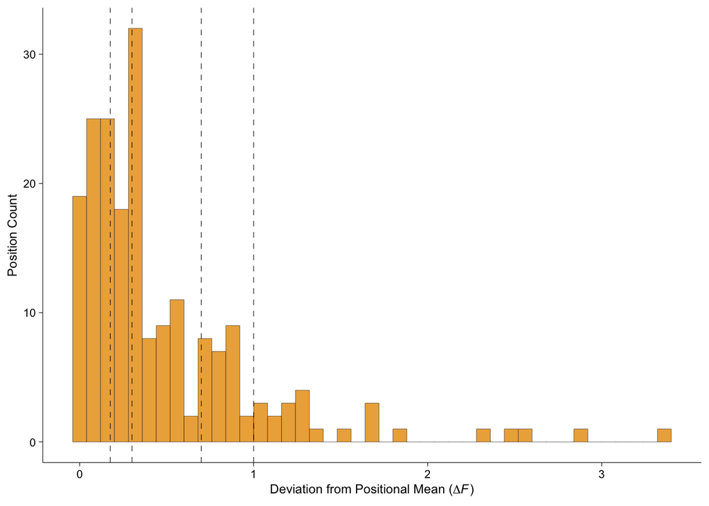

```r
devs_df_wt_1_plot = devs_df_wt %>%
  filter(muts == 1) %>%
  ggplot(aes(x = devs)) +
  geom_histogram(binwidth=0.08, color = "black", lwd = 0.1, fill = "#edae49") +
  geom_vline(xintercept = log10(1.5), lty = 2, lwd = 0.2) +
  geom_vline(xintercept = log10(2), lty = 2, lwd = 0.2) +
  geom_vline(xintercept = log10(5), lty = 2, lwd = 0.2) +
  geom_vline(xintercept = log10(10), lty = 2, lwd = 0.2) +
  labs(x = expression("Deviation from Positional Mean ("*Delta*italic("F")*")"),
       y = "Position Count") +
  theme_classic() +
  theme(axis.line = element_line(size = 0.2, color = "black"), axis.ticks = element_line(size = 0.2, color = "black"), text = element_text(size = 9), axis.text = element_text(size = 8, color = "black"), legend.position = "none")

devs_df_wt_1_plot
```

```r
#ggsave("fig_1D.svg", devs_df_wt_1_plot, width = 180/2, height = 247/4, dpi = 300, units = "mm")
```

## WT heterogenity for Order 2

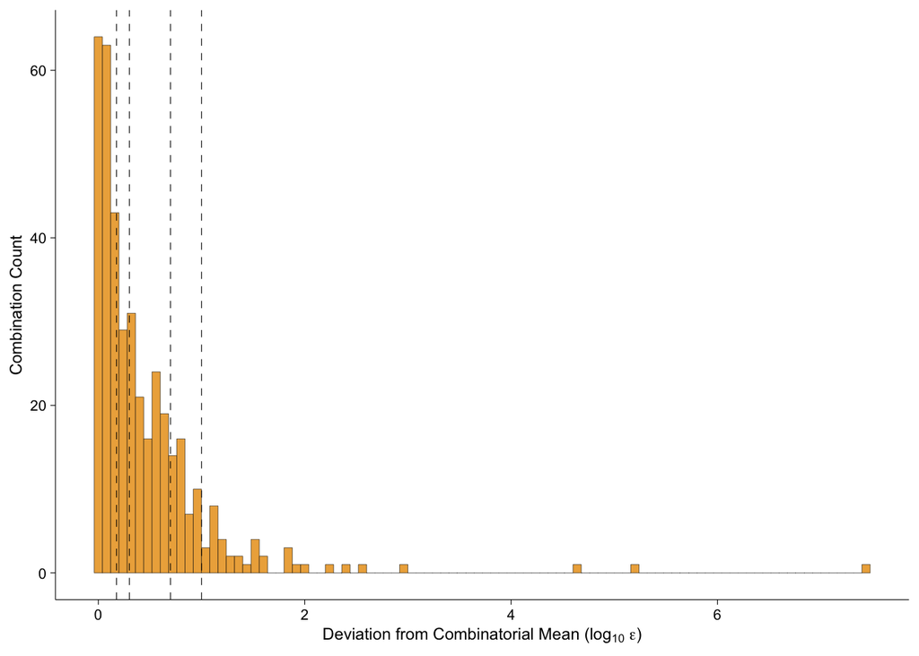

```r
devs_df_wt_2 = devs_df_wt %>%
  filter(muts == 2) %>%
  ggplot(aes(x = devs)) +
  geom_histogram(binwidth=0.08, color = "black", lwd = 0.1, fill = "#edae49") +
  geom_vline(xintercept = log10(1.5), lty = 2, lwd = 0.2) +
  geom_vline(xintercept = log10(2), lty = 2, lwd = 0.2) +
  geom_vline(xintercept = log10(5), lty = 2, lwd = 0.2) +
  geom_vline(xintercept = log10(10), lty = 2, lwd = 0.2) +
  theme_classic() +
  #scale_x_continuous(limits = c(0, 3)) +
  labs(x = expression("Deviation from Combinatorial Mean (log"[10]*" "*epsilon*")"),
       y = "Combination Count") +
  theme(axis.line = element_line(size = 0.2, color = "black"), axis.ticks = element_line(size = 0.2, color = "black"), text = element_text(size = 9), axis.text = element_text(size = 8, color = "black"), legend.position = "none")

devs_df_wt_2
```

```r
#ggsave("fig_sup_4B_1.svg", devs_df_wt_2, width = 180/3, height = 247/4, dpi = 300, units = "mm")
```

## WT heterogenity for Order 3

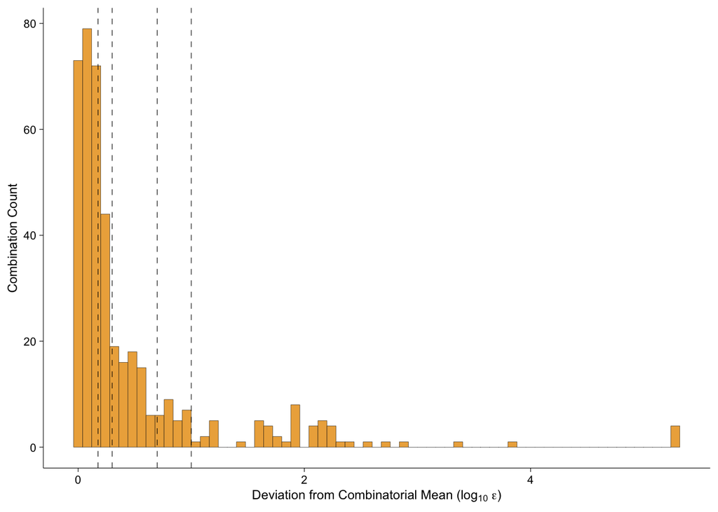

```r
devs_df_wt_3 = devs_df_wt %>%
  filter(muts == 3) %>%
  ggplot(aes(x = devs)) +
  geom_histogram(binwidth=0.08, color = "black", lwd = 0.1, fill = "#edae49") +
  geom_vline(xintercept = log10(1.5), lty = 2, lwd = 0.2) +
  geom_vline(xintercept = log10(2), lty = 2, lwd = 0.2) +
  geom_vline(xintercept = log10(5), lty = 2, lwd = 0.2) +
  geom_vline(xintercept = log10(10), lty = 2, lwd = 0.2) +
  #scale_x_continuous(limits = c(0, 3)) +
  theme_classic() +
  labs(x = expression("Deviation from Combinatorial Mean (log"[10]*" "*epsilon*")"),
       y = "Combination Count") +
  theme(axis.line = element_line(size = 0.2, color = "black"), axis.ticks = element_line(size = 0.2, color = "black"), text = element_text(size = 9), axis.text = element_text(size = 8, color = "black"), legend.position = "none")

devs_df_wt_3
```

```r
#ggsave("fig_sup_4B_2.svg", devs_df_wt_3, width = 180/3, height = 247/4, dpi = 300, units = "mm")
```

## WT heterogenity for Order 4

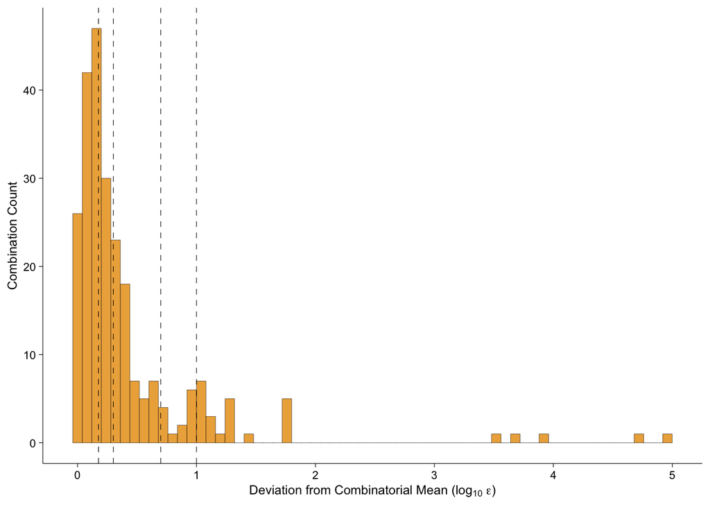

```r
devs_df_wt_4 = devs_df_wt %>%
  filter(muts == 4) %>%
  ggplot(aes(x = devs)) +
  geom_histogram(binwidth=0.08, color = "black", lwd = 0.1, fill = "#edae49") +
  geom_vline(xintercept = log10(1.5), lty = 2, lwd = 0.2) +
  geom_vline(xintercept = log10(2), lty = 2, lwd = 0.2) +
  geom_vline(xintercept = log10(5), lty = 2, lwd = 0.2) +
  geom_vline(xintercept = log10(10), lty = 2, lwd = 0.2) +
  theme_classic() +
  #scale_x_continuous(limits = c(0, 3)) + # Same scale used later
  labs(x = expression("Deviation from Combinatorial Mean (log"[10]*" "*epsilon*")"),
       y = "Combination Count") +
  theme(axis.line = element_line(size = 0.2, color = "black"), axis.ticks = element_line(size = 0.2, color = "black"), text = element_text(size = 9), axis.text = element_text(size = 8, color = "black"), legend.position = "none")

devs_df_wt_4
```

```r
#ggsave("fig_sup_4B_3.svg", devs_df_wt_4, width = 180/3, height = 247/4, dpi = 300, units = "mm")
```

## WT heterogenity for Order 2-4 in facet grid

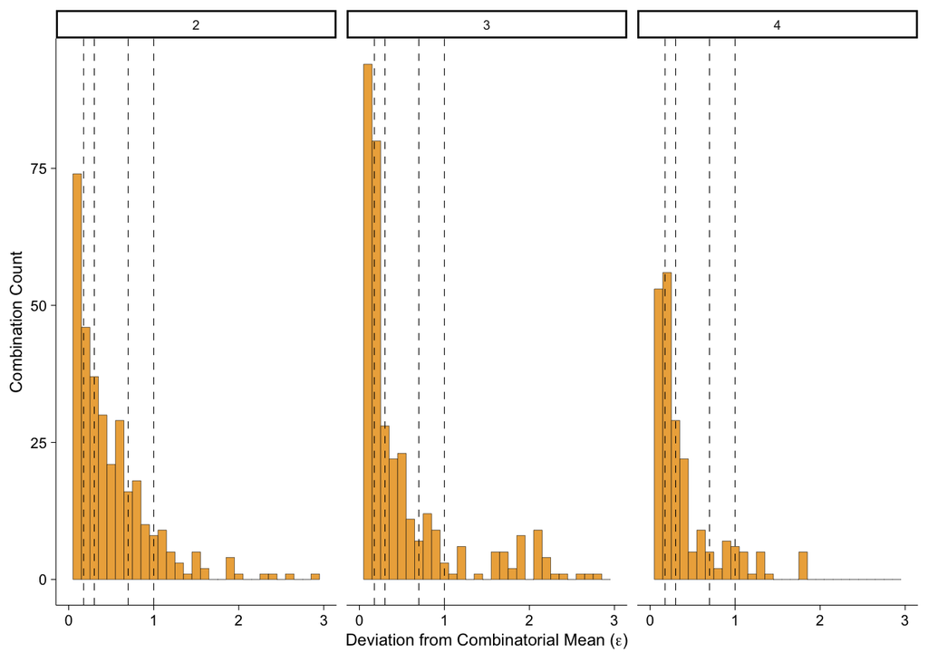

```r
devs_df_wt_multi = devs_df_wt %>%
  filter(muts == 2 | muts == 3 | muts == 4) %>%
  ggplot(aes(x = devs)) +
  geom_histogram(binwidth=0.1, color = "black", lwd = 0.1, fill = "#edae49") +
  geom_vline(xintercept = log10(1.5), lty = 2, lwd = 0.2) +
  geom_vline(xintercept = log10(2), lty = 2, lwd = 0.2) +
  geom_vline(xintercept = log10(5), lty = 2, lwd = 0.2) +
  geom_vline(xintercept = log10(10), lty = 2, lwd = 0.2) +
  facet_grid(~ muts) +
  scale_x_continuous(limits = c(0, 3)) +
  theme_classic() +
  labs(x = expression("Deviation from Combinatorial Mean ("*epsilon*")"),
       y = "Combination Count") +
  theme(axis.line = element_line(size = 0.2, color = "black"), axis.ticks = element_line(size = 0.2, color = "black"), text = element_text(size = 9), axis.text = element_text(size = 8, color = "black"), legend.position = "none")

devs_df_wt_multi
```

```r
#ggsave("fig_2C.svg", devs_df_wt_multi, width = 180, height = 247/4, dpi = 300, units = "mm")
```

Table to show percentages of WT-bg points that deviate from the positional/combinatorial mean by significance threshold (log10 1.5-fold)

```r
devs_df_wt %>%
  mutate(muts = factor(muts)) %>%
  group_by(muts) %>%
  summarise(percent = sum(devs > log10(1.5)) / length(devs),
            outlier = sum(devs > log10(1.5)),
            total = length(devs)) %>%
  knitr::kable()
```

| muts | percent | outlier | total |
| --- | --- | --- | --- |
| 1 | 0.6666667 | 132 | 198 |
| 2 | 0.5949367 | 235 | 395 |
| 3 | 0.5165877 | 218 | 422 |
| 4 | 0.6040816 | 148 | 245 |

Table to show percentages of WT-bg points that deviate from the positional/combinatorial mean by multiple significance threshold (log10 1.5-, 2-, 5-, and 10-fold)

```r
devs_df_wt %>%
  mutate(Order = factor(muts)) %>%
  group_by(Order) %>%
  summarise(percent_1.5 = round(sum(devs > log10(1.5)) / length(devs) *100, 1),
            outlier_1.5 = sum(devs > log10(1.5)),
            percent_2 = round(sum(devs > log10(2)) / length(devs) *100, 1),
            outlier_2 = sum(devs > log10(2)),
            percent_5 = round(sum(devs > log10(5)) / length(devs) *100, 1),
            outlier_5 = sum(devs > log10(5)),
            percent_10 = round(sum(devs > log10(10)) / length(devs) *100, 1),
            outlier_10 = sum(devs > log10(10)),
            total = length(devs)) %>%
  knitr::kable()
```

| Order | percent_1.5 | outlier_1.5 | percent_2 | outlier_2 | percent_5 | outlier_5 | percent_10 | outlier_10 | total |
| --- | --- | --- | --- | --- | --- | --- | --- | --- | --- |
| 1 | 66.7 | 132 | 52.5 | 104 | 24.2 | 48 | 11.6 | 23 | 198 |
| 2 | 59.5 | 235 | 47.8 | 189 | 20.5 | 81 | 9.6 | 38 | 395 |
| 3 | 51.7 | 218 | 34.4 | 145 | 19.0 | 80 | 12.6 | 53 | 422 |
| 4 | 60.4 | 148 | 40.0 | 98 | 16.3 | 40 | 11.0 | 27 | 245 |

## All points to Mean Deviation

Purpose of this analysis was to determine the difference in $\Delta$Function between functional contribution of a given position/combination in any background and the mean contribution of a given position or combination

# Histogram

The spread of all positional contribution vs mean differences for each Order (1-4)

```r
devs = c()
cur_mutations = c()
cur_partial_id = c()
for(i in 1:dim(higher_df_mean)[1]) {
  curr_id = higher_df_mean$unique_id[i]
  devs = c(devs, abs( (higher_df %>% filter(unique_id == curr_id) %>% pull(avg)) - (higher_df_mean$avg[i] ) ))
  cur_mutations = c(cur_mutations, (higher_df %>% filter(unique_id == curr_id) %>% pull(mutations)))
  cur_partial_id = c(cur_partial_id, (higher_df %>% filter(unique_id == curr_id) %>% pull(partial_id)))
}

devs_df = data.frame(devs = devs, muts = cur_mutations, partial_id = cur_partial_id)
```

## All heterogenity for Order 1

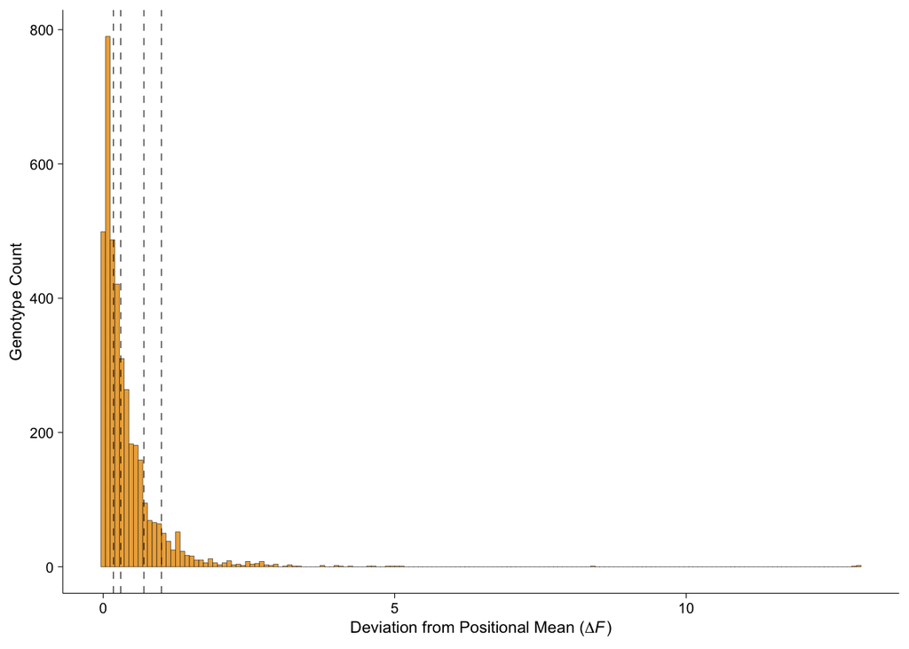

```r
devs_df %>%
  filter(muts == 1) %>%
  ggplot(aes(x = devs)) +
  geom_histogram(binwidth=0.08, color = "black", lwd=0.1, fill = "#edae49") +
  geom_vline(xintercept = log10(1.5), lty = 2, lwd = 0.2) +
  geom_vline(xintercept = log10(2), lty = 2, lwd = 0.2) +
  geom_vline(xintercept = log10(5), lty = 2, lwd = 0.2) +
  geom_vline(xintercept = log10(10), lty = 2, lwd = 0.2) +
  theme_classic() +
  labs(x = expression("Deviation from Positional Mean ("*Delta*italic("F")*")"),
       y = "Genotype Count") +
  theme(axis.line = element_line(size = 0.2, color = "black"), axis.ticks = element_line(size = 0.2, color = "black"), text = element_text(size = 9), axis.text = element_text(size = 8, color = "black"), legend.position = "none")
```

## All heterogenity for Order 2

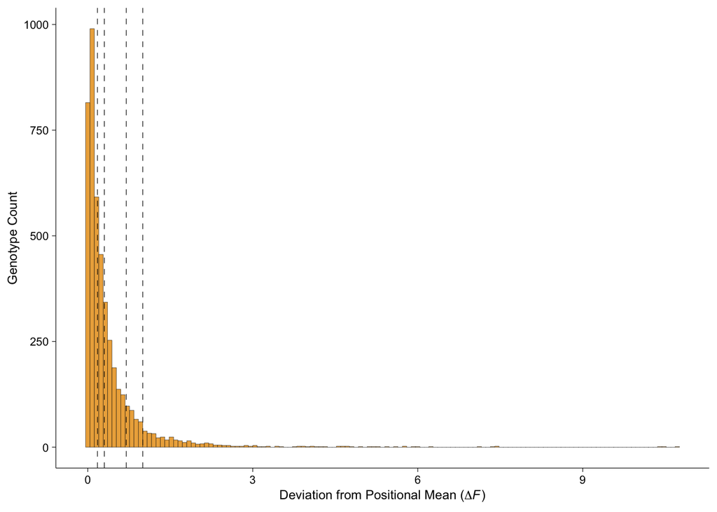

```r
devs_df %>%
  filter(muts == 2) %>%
  ggplot(aes(x = devs)) +
  geom_histogram(binwidth=0.08, color = "black", lwd=0.1, fill = "#edae49") +
  geom_vline(xintercept = log10(1.5), lty = 2, lwd = 0.2) +
  geom_vline(xintercept = log10(2), lty = 2, lwd = 0.2) +
  geom_vline(xintercept = log10(5), lty = 2, lwd = 0.2) +
  geom_vline(xintercept = log10(10), lty = 2, lwd = 0.2) +
  theme_classic() +
  labs(x = expression("Deviation from Positional Mean ("*Delta*italic("F")*")"),
       y = "Genotype Count") +
  theme(axis.line = element_line(size = 0.2, color = "black"), axis.ticks = element_line(size = 0.2, color = "black"), text = element_text(size = 9), axis.text = element_text(size = 8, color = "black"), legend.position = "none")
```

## All heterogenity for Order 3

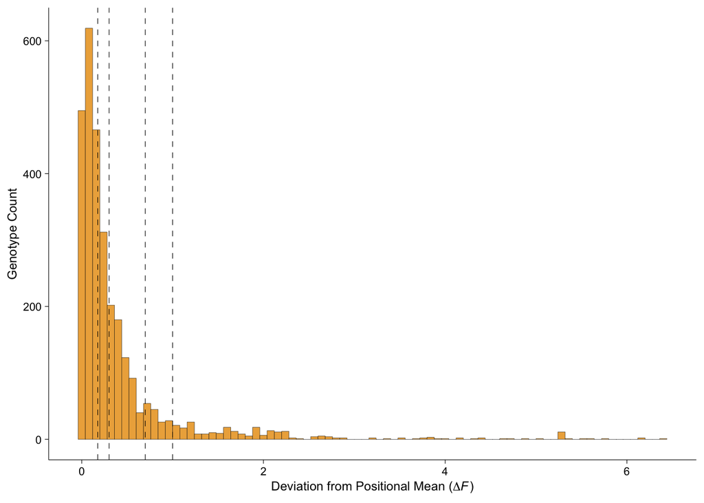

```r
devs_df %>%
  filter(muts == 3) %>%
  ggplot(aes(x = devs)) +
  geom_histogram(binwidth=0.08, color = "black", lwd=0.1, fill = "#edae49") +
  geom_vline(xintercept = log10(1.5), lty = 2, lwd = 0.2) +
  geom_vline(xintercept = log10(2), lty = 2, lwd = 0.2) +
  geom_vline(xintercept = log10(5), lty = 2, lwd = 0.2) +
  geom_vline(xintercept = log10(10), lty = 2, lwd = 0.2) +
  theme_classic() +
  labs(x = expression("Deviation from Positional Mean ("*Delta*italic("F")*")"),
       y = "Genotype Count") +
  theme(axis.line = element_line(size = 0.2, color = "black"), axis.ticks = element_line(size = 0.2, color = "black"), text = element_text(size = 9), axis.text = element_text(size = 8, color = "black"), legend.position = "none")
```

## All heterogenity for Order 4

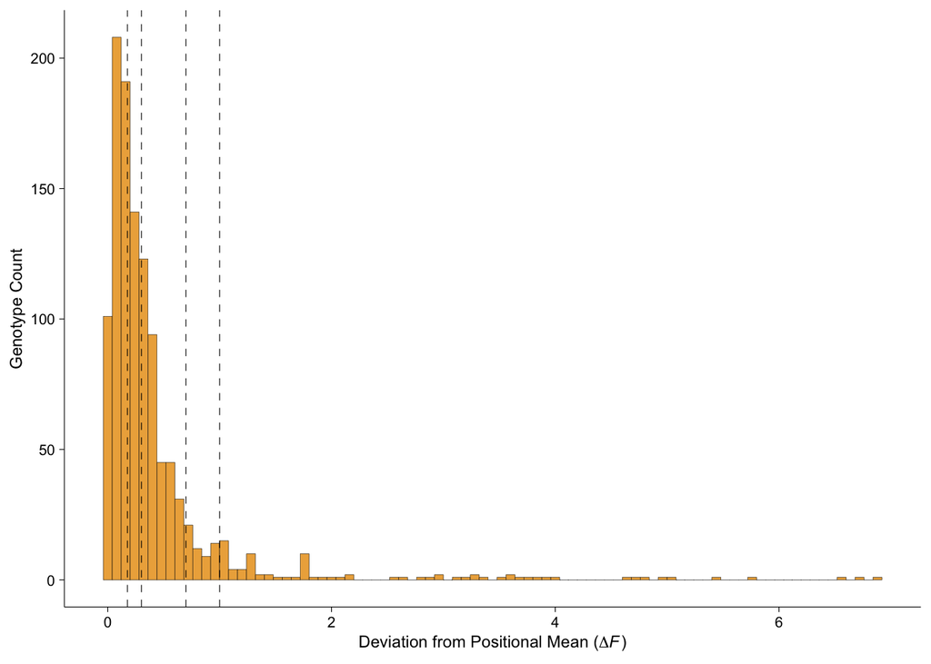

```r
devs_df %>%
  filter(muts == 4) %>%
  ggplot(aes(x = devs)) +
  geom_histogram(binwidth=0.08, color = "black", lwd=0.1, fill = "#edae49") +
  geom_vline(xintercept = log10(1.5), lty = 2, lwd = 0.2) +
  geom_vline(xintercept = log10(2), lty = 2, lwd = 0.2) +
  geom_vline(xintercept = log10(5), lty = 2, lwd = 0.2) +
  geom_vline(xintercept = log10(10), lty = 2, lwd = 0.2) +
  theme_classic() +
  labs(x = expression("Deviation from Positional Mean ("*Delta*italic("F")*")"),
       y = "Genotype Count") +
  theme(axis.line = element_line(size = 0.2, color = "black"), axis.ticks = element_line(size = 0.2, color = "black"), text = element_text(size = 9), axis.text = element_text(size = 8, color = "black"), legend.position = "none")
```

```r
devs_df %>%
  mutate(Order = factor(muts)) %>%
  group_by(Order) %>%
  summarise(percent = sum(devs > log10(1.5)) / length(devs),
            outlier = sum(devs > log10(1.5)),
            total = length(devs)) %>%
  knitr::kable()
```

| Order | percent | outlier | total |
| --- | --- | --- | --- |
| 1 | 0.5800305 | 2283 | 3936 |
| 2 | 0.5148601 | 2356 | 4576 |
| 3 | 0.5091712 | 1499 | 2944 |
| 4 | 0.6017857 | 674 | 1120 |

```r
devs_df %>%
  mutate(Order = factor(muts)) %>%
  group_by(Order) %>%
  summarise(percent_1.5 = sum(devs > log10(1.5)) / length(devs),
            outlier_1.5 = sum(devs > log10(1.5)),
            percent_2 = sum(devs > log10(2)) / length(devs),
            outlier_2 = sum(devs > log10(2)),
            percent_5 = sum(devs > log10(5)) / length(devs),
            outlier_5 = sum(devs > log10(5)),
            percent_10 = sum(devs > log10(10)) / length(devs),
            outlier_10 = sum(devs > log10(10)),
            total = length(devs)) %>%
  knitr::kable()
```

| Order | percent_1.5 | outlier_1.5 | percent_2 | outlier_2 | percent_5 | outlier_5 | percent_10 | outlier_10 | total |
| --- | --- | --- | --- | --- | --- | --- | --- | --- | --- |
| 1 | 0.5800305 | 2283 | 0.4153963 | 1635 | 0.1572663 | 619 | 0.0884146 | 348 | 3936 |
| 2 | 0.5148601 | 2356 | 0.3529283 | 1615 | 0.1440122 | 659 | 0.0804196 | 368 | 4576 |
| 3 | 0.5091712 | 1499 | 0.3383152 | 996 | 0.1348505 | 397 | 0.0889946 | 262 | 2944 |
| 4 | 0.6017857 | 674 | 0.4062500 | 455 | 0.1187500 | 133 | 0.0758929 | 85 | 1120 |

# Individual Trends

This sections attempts to probe if the previous values from the statistical analysis are representative in the individual data sets

### Sign Heterogenity in Invididual datasets

```r
d_individual = d %>% filter_all(any_vars(!is.na(.))) # removes rows with all NA before making unique ID

d_individual = d_individual %>%
  unite("landscape_id", c(enzyme, type, cond), remove = F)

landscape_ids = unique(d_individual$landscape_id)

general_df = tibble()
for(i in 1:length(landscape_ids)) {
  d_curr_individual = d_individual %>% filter(landscape_id == landscape_ids[i])

  general = c(unique(d_curr_individual$enzyme),
    landscape_ids[i],
    sum(d_curr_individual$effects < log10(1/1.5)) / length(d_curr_individual$effects),
    sum(d_curr_individual$effects <= log10(1.5) & d_curr_individual$effects >= log10(1/1.5)) / length(d_curr_individual$effects),
    sum(d_curr_individual$effects > log10(1.5)) / length(d_curr_individual$effects)
  )

  general_df = rbind(general_df, general)
}

colnames(general_df) = c("Enzyme", "Landscape ID", "Negative", "Neutral", "Positive")

general_df[-1]
```

```
##            Landscape ID           Negative           Neutral           Positive
## 1            AP_catef_1             0.8375             0.025             0.1375
## 2         DHFR_ic50_c57              0.375           0.09375            0.53125
## 3         DHFR_ic50_c58              0.375           0.09375            0.53125
## 4         DHFR_ic50_c59            0.28125               0.5            0.21875
## 5         DHFR_ic50_c60            0.21875             0.625            0.15625
## 6         DHFR_ic50_c61              0.125            0.3125             0.5625
## 7      DHFR_ic75_palmer  0.223958333333333              0.25  0.526041666666667
## 8       DHFR_kcat_trajg             0.4125            0.5875                  0
## 9       DHFR_kcat_trajr              0.375             0.625                  0
## 10        DHFR_ki_trajg                  0                 0                  1
## 11        DHFR_ki_trajr                  0                 0                  1
## 12     MPH_catact_CaPTM               0.15            0.1875             0.6625
## 13     MPH_catact_CdPTM             0.1375            0.3375              0.525
## 14     MPH_catact_CoPTM                0.2            0.0875             0.7125
```

[output cut: 27 more lines]

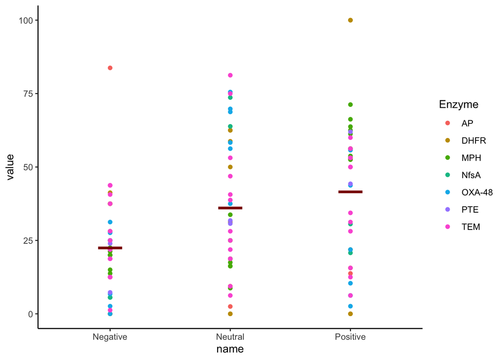

```r
general_df %>%
  pivot_longer(c(3,4,5)) %>%
  mutate(value = as.numeric(value)*100) %>%
  ggplot(aes(x = name, y = value, color = Enzyme)) +
  geom_point() +
  stat_summary(fun=mean, colour="darkred", geom="crossbar", width=0.2) +
  theme_classic()
```

# Prediction

Import the absolute error files for each data set

```r
all_mae = lapply(paste0("trans_Output/", list.files(path = "trans_Output", pattern="aic_*", recursive = T)), read_csv, skip = 1, show_col_types=F, col_names = c("MAE", "Last MAE", "Step", "Enzyme", "Linear MAE", "Linear Last MAE"))

for(element in 1:length(all_mae)){
  all_mae[[element]]$ID = str_split(list.files(path = "Output", pattern="aic_*", recursive = T)[element], "/")[[1]][1]
}

all_mae = do.call("rbind", all_mae)
```

For some reason the absolute error files for OXA-48 CAZ and PIP Traj 1 are including the step 4 model, which uses all 4 of the coefficients in the model for prediction, which is results in a perfect prediction for the WT-background model. I can just remove it manually here

```r
all_mae = all_mae %>% filter(!((ID == "OXA-48_ic50_CAZtraj1" | ID == "OXA-48_ic50_PIPtraj1") & Step == 4))
```

Some statistics for the AE for each model. Now *F* is converted to fold-change in function (but remains WT-normalized)

```r
all_mae %>%
  group_by(Step) %>%
  summarise(wtbg_mean = 10^mean(`Last MAE`),
            wtbg_median = 10^median(`Last MAE`),
            lin_mean = 10^mean(`Linear Last MAE`),
            lin_median = 10^median(`Linear Last MAE`)) %>%
  knitr::kable()
```

| Step | wtbg_mean | wtbg_median | lin_mean | lin_median |
| --- | --- | --- | --- | --- |
| 1 | 33.01911 | 9.246631 | 2.822502 | 2.175932 |
| 2 | 95.83797 | 48.281320 | 1.969366 | 1.706986 |
| 3 | 53.33004 | 6.599577 | 1.314896 | 1.183863 |
| 5 | 26.80878 | 4.350230 | 1.055684 | 1.024498 |
| 6 | 6.66224 | 6.662240 | 1.014927 | 1.014927 |